# IE360 HW2

Fatih ÇETİN

5 Mayıs 2022

## Introduction

In this study, unleaded gasoline sales of a major distributor in 2007 are forecasted using the internal characteristics of the data like trend,seasonality,autocorrelation etc. and the predictors listed below:

- RNUV: An index indicating the rate of new unleaded gasoline using vehicles being added to the traffic in a quarter,
- PU: Average price (adjusted with an index) of a liter of unleaded gasoline in a quarter,
- PG: Average price (adjusted with an index) of a liter of diesel gasoline in a quarter,
- NUGV: Number of unleaded gasoline using vehicles in the traffic,
- NDGV: Number of diesel gasoline using vehicles in the traffic (per 1000 people),
- GNPA: Agriculture component of Gross National Product (adjusted with an index),
- GNPC: Commerce component of Gross National Product (adjusted with an index),
- GNP: Grand total for GNP (agriculture, commerce and other components total).

## Initialization

In the initialization phase the related data is read and after some date manipulation turned into time series objects with the help of xts library. This process can be seen in detail in the code chunk of this section.

```r
# knitr::opts_chunk$set(dev="pdf")
library(lubridate)  #for date manipulation
library(xts) # for time series operations
library(corrplot) # for correlation analysis
library(forecast) # for residual analysis


data_all<-read.csv("IE360_Spring22_HW2_data.csv")


data_all$Quarter<-gsub('_',' ',data_all$Quarter)

data_all$Quarter<-as.yearqtr(data_all$Quarter)


data_all$Unleaded.Gasoline.Sale..UGS.<-as.numeric(gsub(' ','',data_all$Unleaded.Gasoline.Sale..UGS.))
data_all$X..LPG.Vehicles..NLPG.<-as.numeric(gsub(' ','',data_all$X..LPG.Vehicles..NLPG.))
data_all$X..Unleaded.Gasoline.Vehicles..NUGV.<-as.numeric(gsub(' ','',data_all$X..Unleaded.Gasoline.Vehicles..NUGV.))
data_all$GNP.Agriculture<-as.numeric(gsub(' ','',data_all$GNP.Agriculture))
data_all$GNP.Commerce<-as.numeric(gsub(' ','',data_all$GNP.Commerce))
data_all$GNP.Total<-as.numeric(gsub(' ','',data_all$GNP.Total))


data_ts<-xts(x=data_all[-1],order.by=data_all$Quarter,frequency=4)

data_ts$trend<-1:32

storage.mode(data_ts)<-"double"
```

## Visualization and Analysis of the Data

### Plot

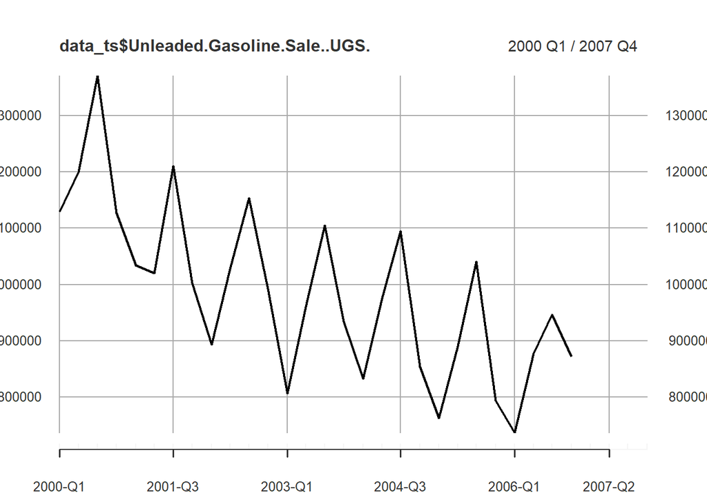

```r
plot(data_ts$Unleaded.Gasoline.Sale..UGS.)
```

There is also a yearly seasonality in the data. It peaks up at the 3rd quarter of every year.

Other than these, the data doesn’t have any unusual behaviour that needs to be included in the model.The independent variables and the internal characteristics of the data will be enough to model its behaviour.

Before building up the model, the correlation of the UGS data with the independent variables should be analyzed to determine which independent variables to use in the model.

## Correlation Analysis

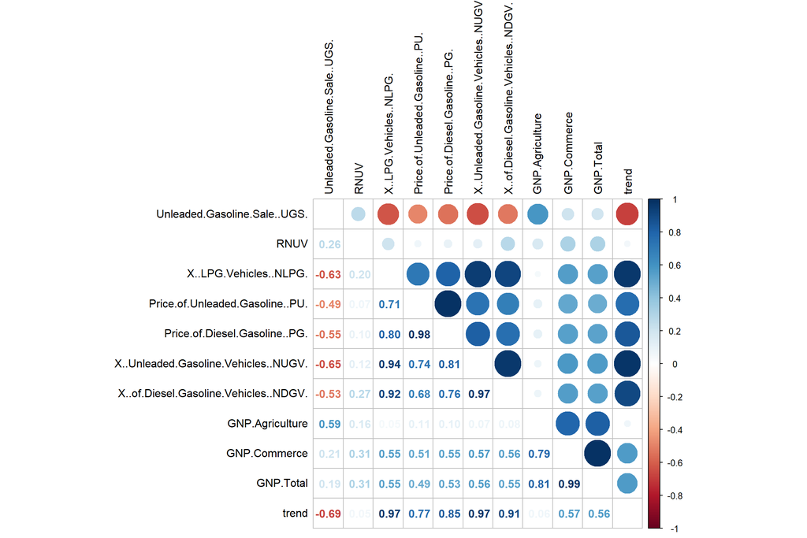

```r
corVals <- cor(data_ts, use="pairwise.complete.obs")

corrplot.mixed(corVals, tl.col="black", tl.pos = "lt")
```

## Checking the Autocorrelation

To have a more clear insight on the data before starting the modelling process, the autocorrelation values should also be checked.

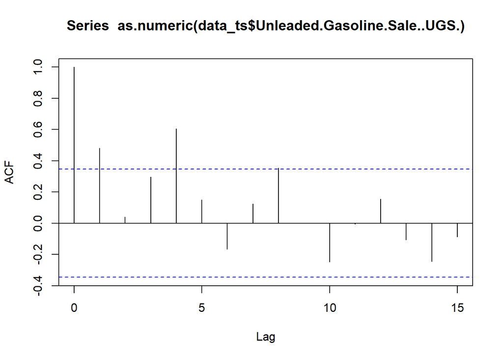

```r
acf(as.numeric(data_ts$Unleaded.Gasoline.Sale..UGS.),na.action = na.pass)
```

In the autocorrelation plot above, the autocorrelation values for lag 1 and lag 4 are above the limits. Thus, they might make good predictors for the target value. However, the lag 4 autocorrelation represents the quarterly seasonality which means there is no use in adding it to a model which already contains seasonality. Thus, the only lagged variable to be used in the model as a predictor is lag 1 series.

## Building Up The Model

### Adding Trend Component

It will be wiser to start building up the model with trend as the most obvious predictor of the data.

```r
model1<-lm(Unleaded.Gasoline.Sale..UGS.~trend,data=data_ts)

summary(model1)
```

```
##
## Call:
## lm(formula = Unleaded.Gasoline.Sale..UGS. ~ trend, data = data_ts)
##
## Residuals:
##     Min      1Q  Median      3Q     Max
## -199945  -73550  -21904   71224  237369
##
## Coefficients:
##             Estimate Std. Error t value Pr(>|t|)
## (Intercept)  1170777      43293  27.043  < 2e-16 ***
## trend         -12660       2608  -4.854 4.95e-05 ***
## ---
## Signif. codes:  0 '***' 0.001 '**' 0.01 '*' 0.05 '.' 0.1 ' ' 1
##
## Residual standard error: 111500 on 26 degrees of freedom
##   (4 observations deleted due to missingness)
## Multiple R-squared:  0.4754, Adjusted R-squared:  0.4552
## F-statistic: 23.56 on 1 and 26 DF,  p-value: 4.945e-05
```

Looking at the summary table, it can be seen that the trend actually is a very significant predictor as expected. Thus, it will remain in the model.

### Adding Seasonality

Then the quarterly seasonality which is the second most obvious predictor should be added to the model.

```r
data_ts$quart<-rep(seq(1:4),8)

model2<-lm(Unleaded.Gasoline.Sale..UGS.~trend+as.factor(quart),data=data_ts)

summary(model2)
```

```
##
## Call:
## lm(formula = Unleaded.Gasoline.Sale..UGS. ~ trend + as.factor(quart),
##     data = data_ts)
##
## Residuals:
##    Min     1Q Median     3Q    Max
## -81167 -31283  -3458  28640  94502
##
## Coefficients:
##                   Estimate Std. Error t value Pr(>|t|)
## (Intercept)        1060372      23653  44.830  < 2e-16 ***
## trend               -13497       1147 -11.764 3.28e-11 ***
## as.factor(quart)2   121532      25987   4.677 0.000104 ***
## as.factor(quart)3   273619      26063  10.498 3.03e-10 ***
## as.factor(quart)4    95049      26189   3.629 0.001405 **
## ---
## Signif. codes:  0 '***' 0.001 '**' 0.01 '*' 0.05 '.' 0.1 ' ' 1
##
## Residual standard error: 48570 on 23 degrees of freedom
##   (4 observations deleted due to missingness)
## Multiple R-squared:  0.9119, Adjusted R-squared:  0.8966
## F-statistic: 59.53 on 4 and 23 DF,  p-value: 8.446e-12
```

Again,as it can be seen in the summary table above, the seasonality component is also significant. So it will remain in the model.

### Adding the Independent Variables

```r
model3<-lm(Unleaded.Gasoline.Sale..UGS.~trend+as.factor(quart)+X..Unleaded.Gasoline.Vehicles..NUGV.,data=data_ts)

summary(model3)
```

```
##
## Call:
## lm(formula = Unleaded.Gasoline.Sale..UGS. ~ trend + as.factor(quart) +
##     X..Unleaded.Gasoline.Vehicles..NUGV., data = data_ts)
##
## Residuals:
##    Min     1Q Median     3Q    Max
## -87256 -30446   1812  27878  86183
##
## Coefficients:
##                                        Estimate Std. Error t value Pr(>|t|)
## (Intercept)                           7.402e+05  5.981e+05   1.238 0.228894
## trend                                -1.592e+04  4.674e+03  -3.406 0.002533 **
## as.factor(quart)2                     1.209e+05  2.643e+04   4.575 0.000148 ***
## as.factor(quart)3                     2.722e+05  2.661e+04  10.229 7.98e-10 ***
## as.factor(quart)4                     9.203e+04  2.720e+04   3.384 0.002673 **
## X..Unleaded.Gasoline.Vehicles..NUGV.  6.856e-02  1.280e-01   0.536 0.597497
## ---
## Signif. codes:  0 '***' 0.001 '**' 0.01 '*' 0.05 '.' 0.1 ' ' 1
##
## Residual standard error: 49340 on 22 degrees of freedom
##   (4 observations deleted due to missingness)
## Multiple R-squared:  0.913,  Adjusted R-squared:  0.8933
## F-statistic:  46.2 on 5 and 22 DF,  p-value: 6.113e-11
```

The predictor X..Unleaded.Gasoline.Vehicles..NUGV. decreased the adjusted R squared value. Thus, it won’t be added to the model.

```r
model4<-lm(Unleaded.Gasoline.Sale..UGS.~trend+as.factor(quart)+X..LPG.Vehicles..NLPG.,data=data_ts)

summary(model4)
```

```
##
## Call:
## lm(formula = Unleaded.Gasoline.Sale..UGS. ~ trend + as.factor(quart) +
##     X..LPG.Vehicles..NLPG., data = data_ts)
##
## Residuals:
##    Min     1Q Median     3Q    Max
## -83022 -23287   3235  18555  90847
##
## Coefficients:
##                          Estimate Std. Error t value Pr(>|t|)
## (Intercept)             8.082e+05  7.363e+04  10.977 2.16e-10 ***
## trend                  -2.422e+04  3.163e+03  -7.657 1.21e-07 ***
## as.factor(quart)2       1.286e+05  2.128e+04   6.044 4.40e-06 ***
## as.factor(quart)3       2.824e+05  2.140e+04  13.200 6.24e-12 ***
## as.factor(quart)4       9.835e+04  2.137e+04   4.601 0.000139 ***
## X..LPG.Vehicles..NLPG.  3.259e-01  9.184e-02   3.549 0.001800 **
## ---
## Signif. codes:  0 '***' 0.001 '**' 0.01 '*' 0.05 '.' 0.1 ' ' 1
##
## Residual standard error: 39600 on 22 degrees of freedom
##   (4 observations deleted due to missingness)
## Multiple R-squared:  0.944,  Adjusted R-squared:  0.9313
## F-statistic: 74.15 on 5 and 22 DF,  p-value: 5.077e-13
```

Then, X..LPG.Vehicles..NLPG. variable is added, and it increased the adjusted R squared value of the model. Thus, it will remain in the model.

```r
model5<-lm(Unleaded.Gasoline.Sale..UGS.~trend+as.factor(quart)+X..LPG.Vehicles..NLPG.+Price.of.Diesel.Gasoline..PG.,data=data_ts)

summary(model5)
```

```
##
## Call:
## lm(formula = Unleaded.Gasoline.Sale..UGS. ~ trend + as.factor(quart) +
##     X..LPG.Vehicles..NLPG. + Price.of.Diesel.Gasoline..PG., data = data_ts)
##
## Residuals:
##    Min     1Q Median     3Q    Max
## -75869 -27199    468  14796  90233
##
## Coefficients:
##                                 Estimate Std. Error t value Pr(>|t|)
## (Intercept)                    9.310e+05  1.276e+05   7.298 3.48e-07 ***
## trend                         -2.198e+04  3.669e+03  -5.992 6.02e-06 ***
## as.factor(quart)2              1.302e+05  2.115e+04   6.158 4.14e-06 ***
## as.factor(quart)3              2.862e+05  2.146e+04  13.338 1.01e-11 ***
## as.factor(quart)4              9.664e+04  2.124e+04   4.549 0.000175 ***
## X..LPG.Vehicles..NLPG.         3.090e-01  9.220e-02   3.351 0.003023 **
## Price.of.Diesel.Gasoline..PG. -3.435e+02  2.927e+02  -1.174 0.253688
## ---
## Signif. codes:  0 '***' 0.001 '**' 0.01 '*' 0.05 '.' 0.1 ' ' 1
##
## Residual standard error: 39270 on 21 degrees of freedom
##   (4 observations deleted due to missingness)
## Multiple R-squared:  0.9474, Adjusted R-squared:  0.9324
## F-statistic: 63.08 on 6 and 21 DF,  p-value: 2.408e-12
```

Then, the variable Price.of.Diesel.Gasoline..PG. is added, and it increased the adjusted R squared value of the model. Thus, it will remain in the model as well.

```r
model6<-lm(Unleaded.Gasoline.Sale..UGS.~trend+as.factor(quart)+X..LPG.Vehicles..NLPG.+Price.of.Diesel.Gasoline..PG.+X..of.Diesel.Gasoline.Vehicles..NDGV.,data=data_ts)

summary(model6)
```

```
##
## Call:
## lm(formula = Unleaded.Gasoline.Sale..UGS. ~ trend + as.factor(quart) +
##     X..LPG.Vehicles..NLPG. + Price.of.Diesel.Gasoline..PG. +
##     X..of.Diesel.Gasoline.Vehicles..NDGV., data = data_ts)
##
## Residuals:
##    Min     1Q Median     3Q    Max
## -82133 -17136   2300  17228  63665
##
## Coefficients:
##                                         Estimate Std. Error t value Pr(>|t|)
## (Intercept)                            5.551e+05  2.494e+05   2.226 0.037679
## trend                                 -2.137e+04  3.525e+03  -6.064 6.30e-06
## as.factor(quart)2                      1.281e+05  2.025e+04   6.327 3.55e-06
## as.factor(quart)3                      2.837e+05  2.056e+04  13.795 1.12e-11
## as.factor(quart)4                      9.189e+04  2.049e+04   4.484 0.000227
## X..LPG.Vehicles..NLPG.                 2.083e-01  1.056e-01   1.972 0.062608
## Price.of.Diesel.Gasoline..PG.         -4.682e+02  2.889e+02  -1.620 0.120809
## X..of.Diesel.Gasoline.Vehicles..NDGV.  1.818e+03  1.052e+03   1.728 0.099354
##
## (Intercept)                           *
## trend                                 ***
## as.factor(quart)2                     ***
## as.factor(quart)3                     ***
## as.factor(quart)4                     ***
## X..LPG.Vehicles..NLPG.                .
## Price.of.Diesel.Gasoline..PG.
## X..of.Diesel.Gasoline.Vehicles..NDGV. .
## ---
## Signif. codes:  0 '***' 0.001 '**' 0.01 '*' 0.05 '.' 0.1 ' ' 1
##
## Residual standard error: 37530 on 20 degrees of freedom
##   (4 observations deleted due to missingness)
## Multiple R-squared:  0.9543, Adjusted R-squared:  0.9383
## F-statistic: 59.61 on 7 and 20 DF,  p-value: 5.112e-12
```

Then, X..of.Diesel.Gasoline.Vehicles..NDGV. variable is added, and it increased the adjusted R squared value of the model. Thus, it will remain in the model as well

.

```r
model7<-lm(Unleaded.Gasoline.Sale..UGS.~trend+as.factor(quart)+X..LPG.Vehicles..NLPG.+Price.of.Diesel.Gasoline..PG.+X..of.Diesel.Gasoline.Vehicles..NDGV.+Price.of.Unleaded.Gasoline..PU.,data=data_ts)

summary(model7)
```

```
##
## Call:
## lm(formula = Unleaded.Gasoline.Sale..UGS. ~ trend + as.factor(quart) +
##     X..LPG.Vehicles..NLPG. + Price.of.Diesel.Gasoline..PG. +
##     X..of.Diesel.Gasoline.Vehicles..NDGV. + Price.of.Unleaded.Gasoline..PU.,
##     data = data_ts)
##
## Residuals:
##    Min     1Q Median     3Q    Max
## -59845 -16242   2673  16566  67430
##
## Coefficients:
##                                         Estimate Std. Error t value Pr(>|t|)
## (Intercept)                            6.365e+05  2.360e+05   2.697 0.014278
## trend                                 -2.315e+04  3.404e+03  -6.802 1.71e-06
## as.factor(quart)2                      1.407e+05  1.989e+04   7.072 9.93e-07
## as.factor(quart)3                      2.889e+05  1.935e+04  14.932 5.96e-12
## as.factor(quart)4                      9.219e+04  1.910e+04   4.826 0.000117
## X..LPG.Vehicles..NLPG.                 1.936e-01  9.875e-02   1.961 0.064709
## Price.of.Diesel.Gasoline..PG.          1.901e+03  1.213e+03   1.567 0.133651
## X..of.Diesel.Gasoline.Vehicles..NDGV.  1.726e+03  9.820e+02   1.757 0.094944
## Price.of.Unleaded.Gasoline..PU.       -1.846e+03  9.217e+02  -2.003 0.059670
##
## (Intercept)                           *
## trend                                 ***
## as.factor(quart)2                     ***
## as.factor(quart)3                     ***
## as.factor(quart)4                     ***
## X..LPG.Vehicles..NLPG.                .
## Price.of.Diesel.Gasoline..PG.
## X..of.Diesel.Gasoline.Vehicles..NDGV. .
## Price.of.Unleaded.Gasoline..PU.       .
## ---
## Signif. codes:  0 '***' 0.001 '**' 0.01 '*' 0.05 '.' 0.1 ' ' 1
##
## Residual standard error: 34990 on 19 degrees of freedom
##   (4 observations deleted due to missingness)
## Multiple R-squared:  0.9622, Adjusted R-squared:  0.9463
## F-statistic: 60.51 on 8 and 19 DF,  p-value: 6.884e-12
```

Then, the variable Price.of.Unleaded.Gasoline..PU. is added to the model, and it increased the adjusted R squared value of the model. Thus, it will remain in the model as well

```r
model8<-lm(Unleaded.Gasoline.Sale..UGS.~trend+as.factor(quart)+X..LPG.Vehicles..NLPG.+Price.of.Diesel.Gasoline..PG.+X..of.Diesel.Gasoline.Vehicles..NDGV.+Price.of.Unleaded.Gasoline..PU.+GNP.Agriculture,data=data_ts)


summary(model8)
```

```
##
## Call:
## lm(formula = Unleaded.Gasoline.Sale..UGS. ~ trend + as.factor(quart) +
##     X..LPG.Vehicles..NLPG. + Price.of.Diesel.Gasoline..PG. +
##     X..of.Diesel.Gasoline.Vehicles..NDGV. + Price.of.Unleaded.Gasoline..PU. +
##     GNP.Agriculture, data = data_ts)
##
## Residuals:
##    Min     1Q Median     3Q    Max
## -59867 -16120   2644  16459  67476
##
## Coefficients:
##                                         Estimate Std. Error t value Pr(>|t|)
## (Intercept)                            6.359e+05  2.453e+05   2.592 0.018389
## trend                                 -2.315e+04  3.531e+03  -6.555 3.69e-06
## as.factor(quart)2                      1.404e+05  2.842e+04   4.939 0.000106
## as.factor(quart)3                      2.860e+05  1.746e+05   1.638 0.118816
## as.factor(quart)4                      9.152e+04  4.548e+04   2.012 0.059407
## X..LPG.Vehicles..NLPG.                 1.934e-01  1.028e-01   1.880 0.076334
## Price.of.Diesel.Gasoline..PG.          1.897e+03  1.262e+03   1.504 0.149936
## X..of.Diesel.Gasoline.Vehicles..NDGV.  1.724e+03  1.018e+03   1.693 0.107713
## Price.of.Unleaded.Gasoline..PU.       -1.842e+03  9.860e+02  -1.868 0.078181
## GNP.Agriculture                        4.956e-04  3.015e-02   0.016 0.987068
##
## (Intercept)                           *
## trend                                 ***
## as.factor(quart)2                     ***
## as.factor(quart)3
## as.factor(quart)4                     .
## X..LPG.Vehicles..NLPG.                .
## Price.of.Diesel.Gasoline..PG.
## X..of.Diesel.Gasoline.Vehicles..NDGV.
## Price.of.Unleaded.Gasoline..PU.       .
## GNP.Agriculture
## ---
## Signif. codes:  0 '***' 0.001 '**' 0.01 '*' 0.05 '.' 0.1 ' ' 1
##
## Residual standard error: 35950 on 18 degrees of freedom
##   (4 observations deleted due to missingness)
## Multiple R-squared:  0.9622, Adjusted R-squared:  0.9434
## F-statistic: 50.96 on 9 and 18 DF,  p-value: 5.611e-11
```

Finally, the variable GNP.Agriculture is added, but it decreased the adjusted R squared value. Thus, it won’t be added to the model.

### Adding the Lagged Variable

```r
data_all$residual_lag1<-c(0,model8$residuals,0,0,0)

data_ts<-xts(x=data_all[-1],order.by=data_all$Quarter,frequency=4)

data_ts$trend<-1:32

data_ts$quart<-rep(seq(1:4),8)

storage.mode(data_ts)<-"double"

model9<-lm(Unleaded.Gasoline.Sale..UGS.~trend+as.factor(quart)+X..LPG.Vehicles..NLPG.+Price.of.Diesel.Gasoline..PG.+X..of.Diesel.Gasoline.Vehicles..NDGV.+Price.of.Unleaded.Gasoline..PU.+residual_lag1,data=data_ts)

summary(model9)
```

```
##
## Call:
## lm(formula = Unleaded.Gasoline.Sale..UGS. ~ trend + as.factor(quart) +
##     X..LPG.Vehicles..NLPG. + Price.of.Diesel.Gasoline..PG. +
##     X..of.Diesel.Gasoline.Vehicles..NDGV. + Price.of.Unleaded.Gasoline..PU. +
##     residual_lag1, data = data_ts)
##
## Residuals:
##    Min     1Q Median     3Q    Max
## -47731 -18293  -1410  18115  48316
##
## Coefficients:
##                                         Estimate Std. Error t value Pr(>|t|)
## (Intercept)                            7.317e+05  2.262e+05   3.235  0.00459
## trend                                 -2.464e+04  3.275e+03  -7.523 5.82e-07
## as.factor(quart)2                      1.496e+05  1.917e+04   7.805 3.48e-07
## as.factor(quart)3                      2.957e+05  1.843e+04  16.042 4.17e-12
## as.factor(quart)4                      1.001e+05  1.832e+04   5.460 3.47e-05
## X..LPG.Vehicles..NLPG.                 2.196e-01  9.333e-02   2.353  0.03020
## Price.of.Diesel.Gasoline..PG.          2.672e+03  1.203e+03   2.222  0.03937
## X..of.Diesel.Gasoline.Vehicles..NDGV.  1.195e+03  9.587e+02   1.246  0.22867
## Price.of.Unleaded.Gasoline..PU.       -2.349e+03  9.006e+02  -2.609  0.01777
## residual_lag1                         -5.267e-01  2.729e-01  -1.930  0.06956
##
## (Intercept)                           **
## trend                                 ***
## as.factor(quart)2                     ***
## as.factor(quart)3                     ***
## as.factor(quart)4                     ***
## X..LPG.Vehicles..NLPG.                *
## Price.of.Diesel.Gasoline..PG.         *
## X..of.Diesel.Gasoline.Vehicles..NDGV.
## Price.of.Unleaded.Gasoline..PU.       *
## residual_lag1                         .
## ---
## Signif. codes:  0 '***' 0.001 '**' 0.01 '*' 0.05 '.' 0.1 ' ' 1
##
## Residual standard error: 32720 on 18 degrees of freedom
##   (4 observations deleted due to missingness)
## Multiple R-squared:  0.9687, Adjusted R-squared:  0.9531
## F-statistic: 61.91 on 9 and 18 DF,  p-value: 1.055e-11
```

Looking at the summary table, the lag 1 variable increased the adjusted R squared value as well. Thus, it will also be added to the model.

## Evaluation of the Model

### R squared analysis

In the summary table above, it can be seen that the final model has an R squared value of 0.9687 which means the 96.87% of the deviation of the data from its mean can be explained using this model. This is clearly very high. Also, its adjusted R squared value is 0.9531 which is also pretty high. This means that thşs model predicts with a high accuracy without using unnecessarily high number of predictors.

### Residual Analysis

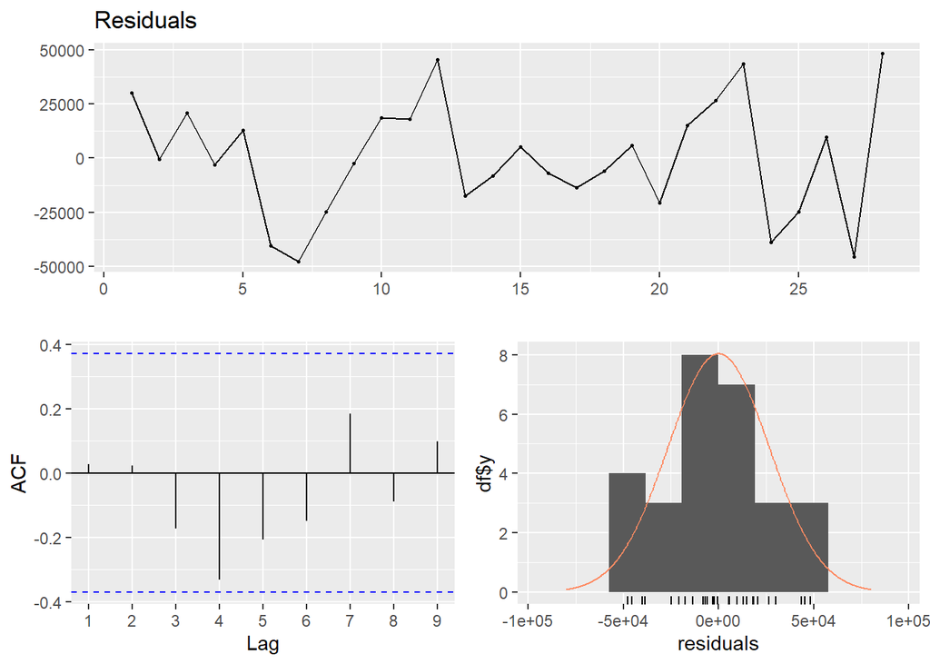

```
##
##  Breusch-Godfrey test for serial correlation of order up to 13
##
## data:  Residuals
## LM test = 24.867, df = 13, p-value = 0.02403
```

```r
checkresiduals(model9)
```

## Prediction

Predicted values of UGS using the final model and the real values between 2000 Q1 - 2007 Q4 are plotted together in the plot below.

### Plot

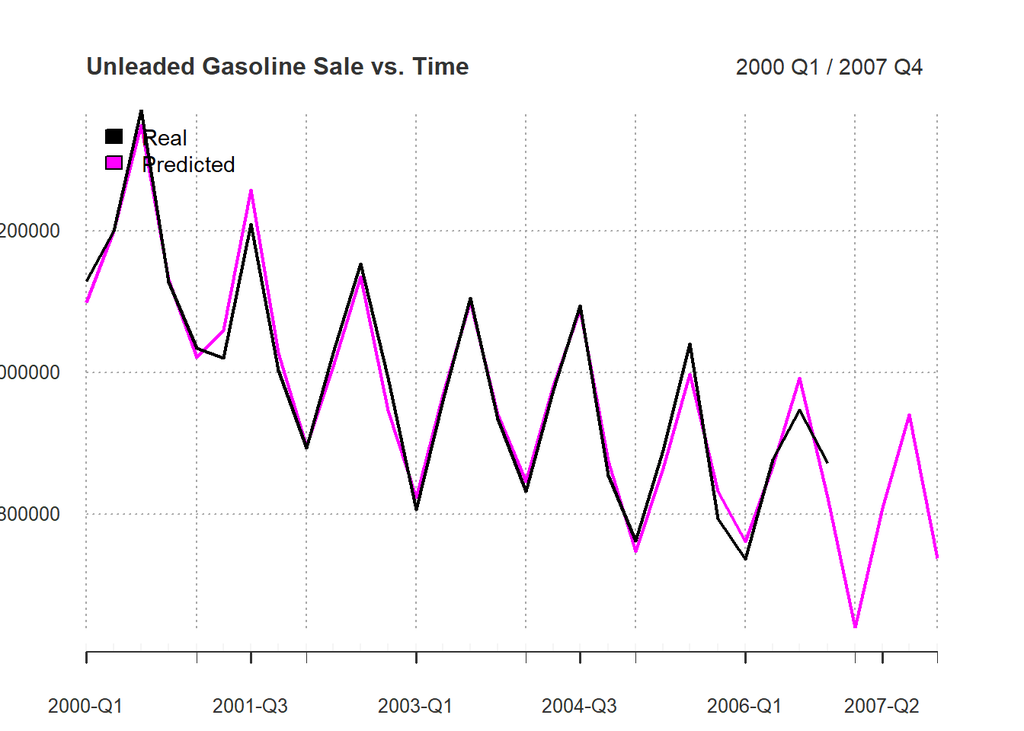

```r
final <- xts(x = data.frame(data_ts$Unleaded.Gasoline.Sale..UGS.[1:32],predict(model9, data_ts)), order.by = data_all$Quarter[1:32], frequency = 4)
colnames(final) <- c("Real", "Predicted")
plot(final,
     legend.loc = "topleft",
     main = "Unleaded Gasoline Sale vs. Time",
     minor.ticks = "years",
     grid.ticks.on = "years",
     yaxis.right = FALSE, col = c("black","magenta"),
     grid.ticks.lty = 3)
```

### Numerical values

The numerical values of the predictions for all the quarters of 2007 is listed below:

```r
prediction<-predict(model9, data_ts)
prediction[29:32]
```

```
##  2007 Q1  2007 Q2  2007 Q3  2007 Q4
## 639614.9 808075.5 940532.6 737457.8
```